# 重賞レース予測レポート【レース終了】

作成日時: 2025/10/26 19:19:22

☞ [マニュアル(pdf)](https://ryutoro-galois.github.io/keiba-predictor/manual/manual.pdf)

☞ 過去5年の同一レース結果: [2024年](https://ryutoro-galois.github.io/keiba-predictor/report/PredResult_2024y_raceDate_20241019_20241020.html), [2023年](https://ryutoro-galois.github.io/keiba-predictor/report/PredResult_2023y_raceDate_20231021_20231022.html), [2022年](https://ryutoro-galois.github.io/keiba-predictor/report/PredResult_2022y_raceDate_20221022_20221023.html), [2021年](https://ryutoro-galois.github.io/keiba-predictor/report/PredResult_2021y_raceDate_20211023_20211024.html), [2020年](https://ryutoro-galois.github.io/keiba-predictor/report/PredResult_2020y_raceDate_20201024_20201025.html)

☞ 過去4週間の別レース結果: [1週前(10/18-19)](https://ryutoro-galois.github.io/keiba-predictor/report/PredResult_2025y_raceDate_20251018_20251019.html), [2週前(10/11-13)](https://ryutoro-galois.github.io/keiba-predictor/report/PredResult_2025y_raceDate_20251011_20251013.html), [3週前(10/5)](https://ryutoro-galois.github.io/keiba-predictor/report/PredResult_2025y_raceDate_20251005_20251005.html), [4週前(9/27-28)](https://ryutoro-galois.github.io/keiba-predictor/report/PredResult_2025y_raceDate_20250927_20250928.html)

☞ netkeiba: [アルテミスステークス(GⅢ)](https://race.netkeiba.com/race/result.html?race_id=202505040811&rf=race_submenu), [菊花賞(GⅠ)](https://race.netkeiba.com/race/result.html?race_id=202508030911&rf=race_submenu)

☞ レース結果(csv): [10/25-26](https://ryutoro-galois.github.io/keiba-predictor/csv/race_result_20251025_20251026.csv)

## 【レース結果(1)】人気と着順の関係

### 【アルテミスステークス(2025/10/25(土))】

【アルテミスステークス(GⅢ)】  
2025/10/25(土), 05_東京, 芝左1600m

[interactive chart not shown]

### 【菊花賞(2025/10/26(日))】

【菊花賞(GⅠ)】  
2025/10/26(日), 08_京都, 芝右外3000m

[interactive chart not shown]

## 【レース結果(2)】コーナー通過順位

### 【アルテミスステークス(2025/10/25(土))】

【アルテミスステークス(GⅢ)】  
2025/10/25(土), 05_東京, 芝左1600m

[interactive chart not shown]

### 【菊花賞(2025/10/26(日))】

【菊花賞(GⅠ)】  
2025/10/26(日), 08_京都, 芝右外3000m

[interactive chart not shown]

## 0. 推し馬予測 (AI予測)

### 【アルテミスステークス(GⅢ) 2025/10/25(土)】

- 本命(◎): 1-3着内確率(勝負強さ)が1位の馬
- 対抗(◯): 1-3着内確率が2-N位(20%程度以上)の中で予測タイムが最も速い馬
- 3番手(▲): 1-3着内確率が2-N位(20%程度以上)のでダークホース確率が最も高い馬
- 穴: ダークホース確率が上位1-M位(40%程度以上)の中で1-3着内確率が最も高い馬

| 推し馬 | 枠番 | 馬番 | 人気 | オッズ | 馬名 | 騎手 | 調教師 | 予測タイム(sec) | 1_順位 | 1-3着内確率(%) | 2_順位 | ﾀﾞｰｸﾎｰｽ確率(%) | 3_順位 |
| --- | --- | --- | --- | --- | --- | --- | --- | --- | --- | --- | --- | --- | --- |
| 本命(◎) | 5 | 5 | 2 | 3.9 | フィロステファニ | 川田将雅 | 中内田充正 | 101.8 | 10.0 | 30.4 | 1 | 0.9 | 9 |
| 対抗(◯) | 7 | 7 | 1 | 2.2 | マルガ | 武豊 | 須貝尚介 | 93.7 | 1.0 | 22.1 | 3 | 0.5 | 10 |
| 3番手(▲) | 1 | 1 | 3 | 6.1 | タイセイボーグ | 佐々木大輔 | 松下武士 | 101.6 | 7.0 | 27.8 | 2 | 1.4 | 7 |
| 穴 | 4 | 4 | 10 | 70.7 | レディーゴール | 菅原明良 | 池添学 | 101.2 | 4.5 | 9.4 | 8 | 42.5 | 1 |

### 【菊花賞(GⅠ) 2025/10/26(日)】

- 本命(◎): 1-3着内確率(勝負強さ)が1位の馬
- 対抗(◯): 1-3着内確率が2-N位(20%程度以上)の中で予測タイムが最も速い馬
- 3番手(▲): 1-3着内確率が2-N位(20%程度以上)のでダークホース確率が最も高い馬
- 穴: ダークホース確率が上位1-M位(40%程度以上)の中で1-3着内確率が最も高い馬

| 推し馬 | 枠番 | 馬番 | 人気 | オッズ | 馬名 | 騎手 | 調教師 | 予測タイム(sec) | 1_順位 | 1-3着内確率(%) | 2_順位 | ﾀﾞｰｸﾎｰｽ確率(%) | 3_順位 |
| --- | --- | --- | --- | --- | --- | --- | --- | --- | --- | --- | --- | --- | --- |
| 本命(◎) | 7 | 15 | 2 | 4.8 | エリキング | 川田将雅 | 中内田充正 | 188.1 | 3.0 | 29.9 | 1 | 0.6 | 15 |
| 対抗(◯) | 5 | 9 | 1 | 4.0 | エネルジコ | Ｃ．ルメール | 高柳瑞樹 | 181.0 | 1.5 | 28.6 | 2 | 0.6 | 16 |
| 3番手(▲) | 2 | 4 | 7 | 13.2 | ヤマニンブークリエ | 横山典弘 | 松永幹夫 | 190.4 | 12.0 | 20.5 | 6 | 1.5 | 12 |
| 穴 | 1 | 2 | 11 | 33.4 | アマキヒ | 戸崎圭太 | 国枝栄 | 190.4 | 12.0 | 16.7 | 8 | 44.4 | 6 |

## 1. 予測チャート (タイム/勝負強さ)

### 【アルテミスステークス(GⅢ)】

2025/10/25(土), 05_東京, 芝左1600m

[interactive chart not shown]

### 【菊花賞(GⅠ)】

2025/10/26(日), 08_京都, 芝右外3000m

[interactive chart not shown]

## 2. オッズモニタリング (毎時)

### 【アルテミスステークス】

[interactive chart not shown]

### 【菊花賞】

[interactive chart not shown]

## 3. 出馬表

### 【アルテミスステークス 2025/10/25(土) 】

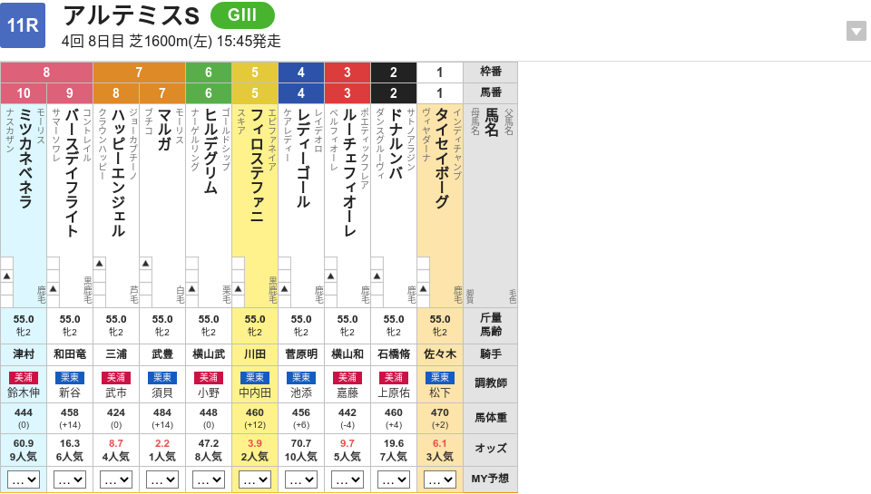

### 【菊花賞 2025/10/26(日) 】

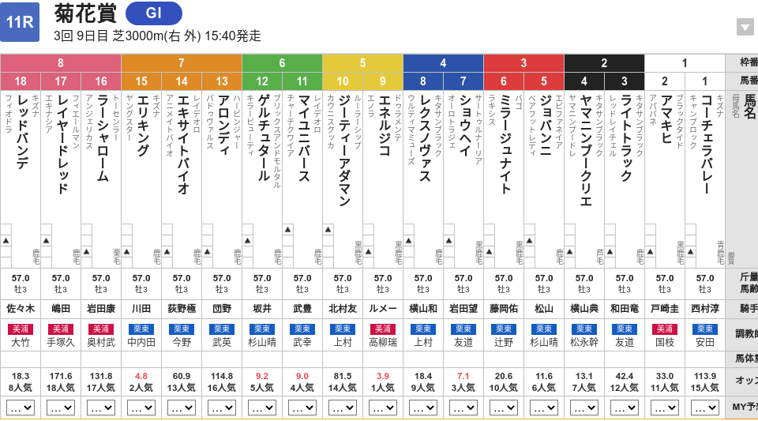

## 4. 単勝予測結果

### 【アルテミスステークス(GⅢ) 2025/10/25(土)】

| 枠番 | 馬番 | 人気 | オッズ | 馬名 | 騎手 | 調教師 | 予測タイム(sec) | 1_順位 | 1-3着内確率(%) | 2_順位 | ﾀﾞｰｸﾎｰｽ確率(%) | 3_順位 |
| --- | --- | --- | --- | --- | --- | --- | --- | --- | --- | --- | --- | --- |
| 1 | 1 | 3 | 6.1 | タイセイボーグ | 佐々木大輔 | 松下武士 | 101.6 | 7.0 | 27.8 | 2 | 1.4 | 7 |
| 2 | 2 | 7 | 19.6 | ドナルンバ | 石橋脩 | 上原佑紀 | 101.2 | 4.5 | 15.2 | 6 | 38.6 | 2 |
| 3 | 3 | 5 | 9.7 | ルーチェフィオーレ | 横山和生 | 嘉藤貴行 | 101.7 | 8.0 | 17.5 | 5 | 1.4 | 6 |
| 4 | 4 | 10 | 70.7 | レディーゴール | 菅原明良 | 池添学 | 101.2 | 4.5 | 9.4 | 8 | 42.5 | 1 |
| 5 | 5 | 2 | 3.9 | フィロステファニ | 川田将雅 | 中内田充正 | 101.8 | 10.0 | 30.4 | 1 | 0.9 | 9 |
| 6 | 6 | 8 | 47.2 | ヒルデグリム | 横山武史 | 小野次郎 | 101.3 | 6.0 | 9.0 | 9 | 30.2 | 4 |
| 7 | 7 | 1 | 2.2 | マルガ | 武豊 | 須貝尚介 | 93.7 | 1.0 | 22.1 | 3 | 0.5 | 10 |
| 7 | 8 | 4 | 8.7 | ハッピーエンジェル | 三浦皇成 | 武市康男 | 100.6 | 2.0 | 19.8 | 4 | 1.2 | 8 |
| 8 | 9 | 6 | 16.3 | バースデイフライト | 和田竜二 | 新谷功一 | 101.7 | 9.0 | 10.7 | 7 | 26.1 | 5 |
| 8 | 10 | 9 | 60.9 | ミツカネベネラ | 津村明秀 | 鈴木伸尋 | 101.2 | 3.0 | 7.8 | 10 | 34.3 | 3 |

### 【菊花賞(GⅠ) 2025/10/26(日)】

| 枠番 | 馬番 | 人気 | オッズ | 馬名 | 騎手 | 調教師 | 予測タイム(sec) | 1_順位 | 1-3着内確率(%) | 2_順位 | ﾀﾞｰｸﾎｰｽ確率(%) | 3_順位 |
| --- | --- | --- | --- | --- | --- | --- | --- | --- | --- | --- | --- | --- |
| 1 | 1 | 15 | 112.5 | コーチェラバレー | 西村淳也 | 安田翔伍 | 190.4 | 12.0 | 11.3 | 12.0 | 55.5 | 4 |
| 1 | 2 | 11 | 33.4 | アマキヒ | 戸崎圭太 | 国枝栄 | 190.4 | 12.0 | 16.7 | 8.0 | 44.4 | 6 |
| 2 | 3 | 12 | 42.2 | ライトトラック | 和田竜二 | 友道康夫 | 190.4 | 12.0 | 10.9 | 18.0 | 44.1 | 7 |
| 2 | 4 | 7 | 13.2 | ヤマニンブークリエ | 横山典弘 | 松永幹夫 | 190.4 | 12.0 | 20.5 | 6.0 | 1.5 | 12 |
| 3 | 5 | 6 | 11.4 | ジョバンニ | 松山弘平 | 杉山晴紀 | 190.4 | 6.0 | 21.8 | 5.0 | 1.0 | 13 |
| 3 | 6 | 10 | 21.0 | ミラージュナイト | 藤岡佑介 | 辻野泰之 | 190.4 | 12.0 | 15.6 | 9.0 | 44.0 | 8 |
| 4 | 7 | 3 | 6.9 | ショウヘイ | 岩田望来 | 友道康夫 | 190.4 | 12.0 | 24.7 | 4.0 | 0.6 | 17 |
| 4 | 8 | 9 | 18.4 | レクスノヴァス | 横山和生 | 上村洋行 | 190.4 | 12.0 | 13.8 | 11.0 | 1.8 | 10 |
| 5 | 9 | 1 | 4.0 | エネルジコ | Ｃ．ルメール | 高柳瑞樹 | 181.0 | 1.5 | 28.6 | 2.0 | 0.6 | 16 |
| 5 | 10 | 14 | 81.4 | ジーティーアダマン | 北村友一 | 上村洋行 | 181.0 | 1.5 | 11.0 | 16.5 | 45.4 | 5 |

[output cut: 8 more lines]

## 5. 人気と着順の乖離率推移

### 【アルテミスステークス_2014y_2019y】

[interactive chart not shown]

### 【菊花賞_1990y_2019y】

[interactive chart not shown]

### 【アルテミスステークス_2014y_2019y】

| No | 開催年 | 不整合率(%) | 頭数 | 人気別着順(1-3位) | 人気別着順(全体) |
| --- | --- | --- | --- | --- | --- |
| 6 | 2019 | 8.8 | 9頭 | 1-2-5 | 1\|2\|5\|3\|6\|4\|7\|8\|9 |
| 5 | 2018 | 59.7 | 15頭 | 6-5-2 | 6\|5\|2\|4\|7\|14\|8\|3\|9\|10\|1\|12\|11\|15\|13 |
| 4 | 2017 | 37.9 | 15頭 | 2-13-4 | 2\|13\|4\|6\|9\|1\|12\|8\|10\|3\|14\|7\|5\|11\|15 |
| 3 | 2016 | 19.7 | 18頭 | 1-2-5 | 1\|2\|5\|6\|4\|10\|7\|15\|8\|14\|9\|3\|12\|11\|13\|16\|17\|18 |
| 2 | 2015 | 36.9 | 15頭 | 12-1-6 | 12\|1\|6\|9\|5\|4\|2\|11\|15\|10\|13\|8\|3\|14\|7 |
| 1 | 2014 | 35.8 | 17頭 | 9-1-11 | 9\|1\|11\|5\|7\|3\|6\|2\|4\|8\|14\|13\|16\|12\|15\|10\|17 |

### 【菊花賞_1990y_2019y】

| No | 開催年 | 不整合率(%) | 頭数 | 人気別着順(1-3位) | 人気別着順(全体) |
| --- | --- | --- | --- | --- | --- |
| 30 | 2019 | 37.3 | 18頭 | 3-8-1 | 3\|8\|1\|16\|12\|7\|11\|13\|2\|4\|5\|15\|6\|18\|10\|14\|17\|9 |
| 29 | 2018 | 29.9 | 18頭 | 7-2-10 | 7\|2\|10\|1\|12\|13\|15\|3\|4\|8\|11\|9\|6\|5\|14\|17\|18\|16 |
| 28 | 2017 | 33.6 | 18頭 | 1-10-13 | 1\|10\|13\|11\|4\|3\|2\|16\|18\|6\|5\|12\|9\|14\|8\|7\|17\|15 |
| 27 | 2016 | 19.9 | 18頭 | 1-9-6 | 1\|9\|6\|2\|4\|7\|12\|3\|5\|8\|11\|10\|13\|18\|14\|15\|17\|16 |
| 26 | 2015 | 29.5 | 18頭 | 5-2-1 | 5\|2\|1\|6\|3\|7\|8\|11\|10\|12\|4\|13\|18\|9\|15\|17\|14\|16 |
| 25 | 2014 | 54.4 | 18頭 | 3-4-7 | 3\|4\|7\|10\|6\|9\|13\|5\|1\|12\|11\|8\|14\|17\|15\|2\|18\|16 |
| 24 | 2013 | 33.8 | 18頭 | 1-5-3 | 1\|5\|3\|8\|7\|6\|15\|11\|18\|9\|16\|12\|2\|13\|4\|10\|17\|14 |
| 23 | 2012 | 35.8 | 18頭 | 1-5-7 | 1\|5\|7\|10\|11\|3\|12\|4\|2\|8\|13\|17\|16\|6\|14\|15\|9\|18 |
| 22 | 2011 | 11.4 | 18頭 | 1-2-3 | 1\|2\|3\|14\|7\|13\|4\|8\|11\|5\|17\|16\|18\|15\|9\|10\|6\|12 |
| 21 | 2010 | 22.9 | 18頭 | 7-1-13 | 7\|1\|13\|5\|11\|2\|3\|9\|4\|10\|6\|16\|14\|12\|8\|17\|18\|15 |

[output cut: 20 more lines]

## 6. 1-3番人気馬の着順分類予測

### 【アルテミスステークス】

| 分類 | 凡例 | 発生確率(%) | 当該レース | 当該レースランク | 直近1年間 |
| --- | --- | --- | --- | --- | --- |
| 4: 1,2番人気のみ (4_pop12) | 1 \| 2 \| * | 18.1 | 0.28 | 0.28 | 0.36 |
| 1: 1番人気のみ (1_pop1) | 1 \| * \| * | 17.3 | 0.95 | 0.95 | 0.00 |
| 5: 1,3番人気のみ (5_pop13) | 1 \| 3 \| * | 14.1 | 0.00 | 0.00 | 0.28 |
| 8: 1,2,3番人気すべて着外 (8_darkhorse) | * \| * \| * | 14.1 | 0.00 | 0.00 | 0.00 |
| 2: 2番人気のみ (2_pop2) | 2 \| * \| * | 10.0 | 0.55 | 0.55 | 0.00 |
| 6: 2,3番人気のみ (6_pop23) | 2 \| 3 \| * | 9.8 | 0.00 | 0.00 | 0.00 |
| 3: 3番人気のみ (3_pop3) | 3 \| * \| * | 9.4 | 0.00 | 0.00 | 0.00 |
| 7: 1,2,3番人気すべて着内 (7_pop123) | 1 \| 2 \| 3 | 7.1 | 0.00 | 0.00 | 0.00 |

### 【菊花賞】

| 分類 | 凡例 | 発生確率(%) | 当該レース | 当該レースランク | 直近1年間 |
| --- | --- | --- | --- | --- | --- |
| 4: 1,2番人気のみ (4_pop12) | 1 \| 2 \| * | 18.1 | 1.27 | 1.27 | 0.00 |
| 1: 1番人気のみ (1_pop1) | 1 \| * \| * | 17.3 | 0.86 | 0.86 | 0.00 |
| 5: 1,3番人気のみ (5_pop13) | 1 \| 3 \| * | 14.1 | 0.55 | 0.55 | 0.14 |
| 8: 1,2,3番人気すべて着外 (8_darkhorse) | * \| * \| * | 14.1 | 1.64 | 1.64 | 0.00 |
| 2: 2番人気のみ (2_pop2) | 2 \| * \| * | 10.0 | 3.45 | 3.45 | 0.00 |
| 6: 2,3番人気のみ (6_pop23) | 2 \| 3 \| * | 9.8 | 0.86 | 0.86 | 0.00 |
| 3: 3番人気のみ (3_pop3) | 3 \| * \| * | 9.4 | 1.09 | 1.09 | 0.00 |
| 7: 1,2,3番人気すべて着内 (7_pop123) | 1 \| 2 \| 3 | 7.1 | 0.83 | 0.83 | 0.00 |

## 7. 3連複予測結果

### 【アルテミスステークス(GⅢ) 2025/10/25(土)】

| 分類 | 馬番 | 枠番 | 人気 | 平均予測タイム(sec) | 1-3着内確率(%) | ﾀﾞｰｸﾎｰｽ確率(%) | 馬名 | 騎手 | 調教師 |
| --- | --- | --- | --- | --- | --- | --- | --- | --- | --- |
| 7: 1,2,3番人気すべて着内 (7_pop123) | 7-5-1 | 7-5-1 | 1-2-3 | 99.03 | 1.87 | 0.00 | マルガ \| フィロステファニ \| タイセイボーグ | 武豊 \| 川田将雅 \| 佐々木大輔 | 須貝尚介 \| 中内田充正 \| 松下武士 |
| 6: 2,3番人気のみ (6_pop23) | 5-1-8 | 5-1-7 | 2-3-4 | 101.33 | 1.67 | 0.00 | フィロステファニ \| タイセイボーグ \| ハッピーエンジェル | 川田将雅 \| 佐々木大輔 \| 三浦皇成 | 中内田充正 \| 松下武士 \| 武市康男 |
| 6: 2,3番人気のみ (6_pop23) | 5-1-3 | 5-1-3 | 2-3-5 | 101.70 | 1.48 | 0.00 | フィロステファニ \| タイセイボーグ \| ルーチェフィオーレ | 川田将雅 \| 佐々木大輔 \| 横山和生 | 中内田充正 \| 松下武士 \| 嘉藤貴行 |
| 4: 1,2番人気のみ (4_pop12) | 7-5-8 | 7-5-7 | 1-2-4 | 98.70 | 1.33 | 0.00 | マルガ \| フィロステファニ \| ハッピーエンジェル | 武豊 \| 川田将雅 \| 三浦皇成 | 須貝尚介 \| 中内田充正 \| 武市康男 |
| 6: 2,3番人気のみ (6_pop23) | 5-1-2 | 5-1-2 | 2-3-7 | 101.53 | 1.29 | 0.00 | フィロステファニ \| タイセイボーグ \| ドナルンバ | 川田将雅 \| 佐々木大輔 \| 石橋脩 | 中内田充正 \| 松下武士 \| 上原佑紀 |
| 5: 1,3番人気のみ (5_pop13) | 7-1-8 | 7-1-7 | 1-3-4 | 98.63 | 1.22 | 0.00 | マルガ \| タイセイボーグ \| ハッピーエンジェル | 武豊 \| 佐々木大輔 \| 三浦皇成 | 須貝尚介 \| 松下武士 \| 武市康男 |
| 4: 1,2番人気のみ (4_pop12) | 7-5-3 | 7-5-3 | 1-2-5 | 99.07 | 1.18 | 0.00 | マルガ \| フィロステファニ \| ルーチェフィオーレ | 武豊 \| 川田将雅 \| 横山和生 | 須貝尚介 \| 中内田充正 \| 嘉藤貴行 |
| 5: 1,3番人気のみ (5_pop13) | 7-1-3 | 7-1-3 | 1-3-5 | 99.00 | 1.08 | 0.00 | マルガ \| タイセイボーグ \| ルーチェフィオーレ | 武豊 \| 佐々木大輔 \| 横山和生 | 須貝尚介 \| 松下武士 \| 嘉藤貴行 |
| 2: 2番人気のみ (2_pop2) | 5-8-3 | 5-7-3 | 2-4-5 | 101.37 | 1.05 | 0.00 | フィロステファニ \| ハッピーエンジェル \| ルーチェフィオーレ | 川田将雅 \| 三浦皇成 \| 横山和生 | 中内田充正 \| 武市康男 \| 嘉藤貴行 |
| 4: 1,2番人気のみ (4_pop12) | 7-5-2 | 7-5-2 | 1-2-7 | 98.90 | 1.02 | 0.00 | マルガ \| フィロステファニ \| ドナルンバ | 武豊 \| 川田将雅 \| 石橋脩 | 須貝尚介 \| 中内田充正 \| 上原佑紀 |

[output cut: 110 more lines]

### 【菊花賞(GⅠ) 2025/10/26(日)】

| 分類 | 馬番 | 枠番 | 人気 | 平均予測タイム(sec) | 1-3着内確率(%) | ﾀﾞｰｸﾎｰｽ確率(%) | 馬名 | 騎手 | 調教師 |
| --- | --- | --- | --- | --- | --- | --- | --- | --- | --- |
| 4: 1,2番人気のみ (4_pop12) | 9-15-11 | 5-7-6 | 1-2-4 | 189.00 | 2.12 | 0.00 | エネルジコ \| エリキング \| マイユニバース | Ｃ．ルメール \| 川田将雅 \| 武豊 | 高柳瑞樹 \| 中内田充正 \| 武幸四郎 |
| 7: 1,2,3番人気すべて着内 (7_pop123) | 9-15-7 | 5-7-4 | 1-2-3 | 186.50 | 2.11 | 0.00 | エネルジコ \| エリキング \| ショウヘイ | Ｃ．ルメール \| 川田将雅 \| 岩田望来 | 高柳瑞樹 \| 中内田充正 \| 友道康夫 |
| 4: 1,2番人気のみ (4_pop12) | 9-15-5 | 5-7-3 | 1-2-6 | 186.50 | 1.86 | 0.00 | エネルジコ \| エリキング \| ジョバンニ | Ｃ．ルメール \| 川田将雅 \| 松山弘平 | 高柳瑞樹 \| 中内田充正 \| 杉山晴紀 |
| 6: 2,3番人気のみ (6_pop23) | 15-7-11 | 7-4-6 | 2-3-4 | 192.13 | 1.83 | 0.00 | エリキング \| ショウヘイ \| マイユニバース | 川田将雅 \| 岩田望来 \| 武豊 | 中内田充正 \| 友道康夫 \| 武幸四郎 |
| 4: 1,2番人気のみ (4_pop12) | 9-15-4 | 5-7-2 | 1-2-7 | 186.50 | 1.75 | 0.00 | エネルジコ \| エリキング \| ヤマニンブークリエ | Ｃ．ルメール \| 川田将雅 \| 横山典弘 | 高柳瑞樹 \| 中内田充正 \| 松永幹夫 |
| 5: 1,3番人気のみ (5_pop13) | 9-7-11 | 5-4-6 | 1-3-4 | 189.77 | 1.75 | 0.00 | エネルジコ \| ショウヘイ \| マイユニバース | Ｃ．ルメール \| 岩田望来 \| 武豊 | 高柳瑞樹 \| 友道康夫 \| 武幸四郎 |
| 4: 1,2番人気のみ (4_pop12) | 9-15-12 | 5-7-6 | 1-2-5 | 186.50 | 1.67 | 0.00 | エネルジコ \| エリキング \| ゲルチュタール | Ｃ．ルメール \| 川田将雅 \| 坂井瑠星 | 高柳瑞樹 \| 中内田充正 \| 杉山晴紀 |
| 2: 2番人気のみ (2_pop2) | 15-11-5 | 7-6-3 | 2-4-6 | 192.13 | 1.61 | 0.00 | エリキング \| マイユニバース \| ジョバンニ | 川田将雅 \| 武豊 \| 松山弘平 | 中内田充正 \| 武幸四郎 \| 杉山晴紀 |
| 6: 2,3番人気のみ (6_pop23) | 15-7-5 | 7-4-3 | 2-3-6 | 189.63 | 1.61 | 0.00 | エリキング \| ショウヘイ \| ジョバンニ | 川田将雅 \| 岩田望来 \| 松山弘平 | 中内田充正 \| 友道康夫 \| 杉山晴紀 |
| 1: 1番人気のみ (1_pop1) | 9-11-5 | 5-6-3 | 1-4-6 | 189.77 | 1.55 | 0.00 | エネルジコ \| マイユニバース \| ジョバンニ | Ｃ．ルメール \| 武豊 \| 松山弘平 | 高柳瑞樹 \| 武幸四郎 \| 杉山晴紀 |

[output cut: 806 more lines]

## 8. 直近の全レース情報

[output not shown]

[output cut: 10 more lines]